Name :- Vaishali Kailash Pawar Student Number :- 0559388 Study Programme :- Master of Science in Applied Sciences and Engineering : Computer Science(Artificial Intelligence) Title of Project:- Regression

# Linear Regression

```python
import pandas as pd
import numpy as np
import random
import timeit
import pylab
import matplotlib.pyplot as plt
%matplotlib inline
```

Linear regression does the task of predicting the dependent variable value i.e. y based on a given independent variable i.e. x. So, the linear regression founds the linear relationship between input and output. As it found the linear relationship between the input and output, it has a name as linear regression. Linear regression gives the straight line that best fits the data points, when we plot a independent variable (x) on the x-axis and dependent variable (y) on the y-axis. Linear regression predict a dependent variable value (y) based on a given independent variable (x). So, the linear regression techniques finds a linear relationship between x which is input and y which is a output. Hence, it has a name as Linear regression.

The equation of the above line is : Y = mx + b

Where b is the intercept and m is the slope of the line. So, the linear regression algorithm gives the most optimal value for the intercept and the slope. The value of y and x variables are the data features and it can not be changed, so its value remains the same. The values that we can control are the intercept i.e. b and slope i.e. m.

The concept can be extended to the cases where there are more than two variables. This is called multiple linear regression. For example, consider the cases where we want to predict the number of rooms in a house, price of the house based upon its area, the average income of the people in the area, the age of the house, and so on. In this case the target variable i.e the dependent variable is dependent on several independent variables. A regression model involving multiple variables can be represented as:

y = b0 + m1b1 + m2b2 + m3b3 + … … mnbn

This is the equation of a hyperplane. A linear regression model in two dimensions is a straight line, in three dimensions it is a plane, and in more than three dimensions, a hyperplane.

For training the Linear regression model, we need to import LinearRegression class, instantiate it, and call the fit() method along with our training data.

```python
import matplotlib.pyplot as plt
import numpy as np
from sklearn import datasets,linear_model
from sklearn.metrics import mean_squared_error,r2_score
diabetes=datasets.load_diabetes()
diabetes_X=diabetes.data[:,np.newaxis,2]
diabetes_X_train=diabetes_X[:-30] #splitting data into training and test sets
diabetes_X_test=diabetes_X[-30:]
diabetes_y_train=diabetes.target[:-30] #splitting targets into training and test sets
diabetes_y_test=diabetes.target[-30:]
regr=linear_model.LinearRegression() #Linear regression object
regr.fit(diabetes_X_train,diabetes_y_train) #Use training sets to train the model
```

```
LinearRegression(copy_X=True, fit_intercept=True, n_jobs=None, normalize=False)
```

Linear regrssion model founds the best value for the intercept and slope which results in a line that best fits the data. We can execute the following code to see the value of a intercept and slope calculated by the linear regression algorithm for our datasets.

```python
#Now we can do the prediction on test data as follows:

diabetes_y_pred=regr.predict(diabetes_X_test) #Make predictions
print(regr.intercept_)
regr.coef_
```

```
153.39713623331698
```

```
array([941.43097333])
```

We can check the difference between the actual value and predicted value as follows:

```python
df = pd.DataFrame({'Actual': diabetes_y_test, 'Predicted': diabetes_y_pred})
df
```

|  | Actual | Predicted |
| --- | --- | --- |
| 0 | 261.0 | 233.802941 |
| 1 | 113.0 | 152.628087 |
| 2 | 131.0 | 159.730887 |
| 3 | 174.0 | 161.760258 |
| 4 | 257.0 | 228.729512 |
| 5 | 55.0 | 220.612027 |
| 6 | 84.0 | 130.305002 |
| 7 | 42.0 | 101.893804 |
| 8 | 146.0 | 119.143460 |
| 9 | 212.0 | 168.863058 |
| 10 | 233.0 | 226.700141 |
| 11 | 91.0 | 116.099403 |
| 12 | 111.0 | 163.789630 |
| 13 | 152.0 | 115.084717 |
| 14 | 120.0 | 121.172831 |
| 15 | 67.0 | 158.716201 |
| 16 | 310.0 | 236.846998 |
| 17 | 94.0 | 122.187517 |
| 18 | 183.0 | 99.864432 |
| 19 | 66.0 | 124.216888 |
| 20 | 173.0 | 205.391742 |
| 21 | 72.0 | 96.820375 |
| 22 | 49.0 | 154.657458 |
| 23 | 64.0 | 131.319688 |
| 24 | 48.0 | 83.629462 |
| 25 | 178.0 | 171.907115 |
| 26 | 104.0 | 138.422488 |
| 27 | 132.0 | 138.422488 |
| 28 | 220.0 | 190.171457 |
| 29 | 57.0 | 84.644147 |

We can plot for the comparison of Actual and Predicted values is as follows:

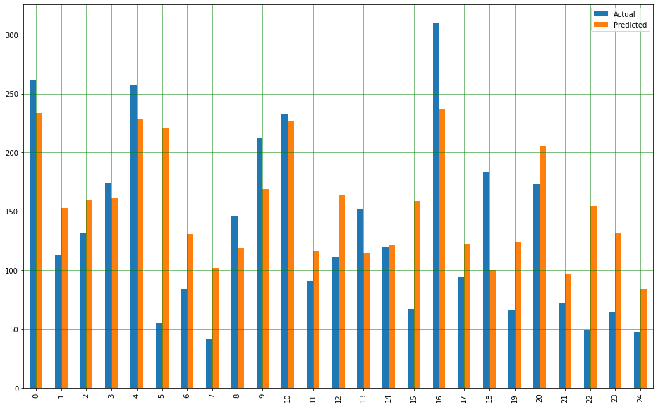

```python
df1 = df.head(25)
df1.plot(kind='bar',figsize=(16,10))
plt.grid(which='major', linestyle='-', linewidth='0.5', color='green')
plt.grid(which='minor', linestyle=':', linewidth='0.5', color='black')
plt.show()
```

```python
mean_squared_error(diabetes_y_test,diabetes_y_pred)
```

```
3035.0601152912695
```

```python
r2_score(diabetes_y_test,diabetes_y_pred) #Variance score
```

```
0.410920728135835
```

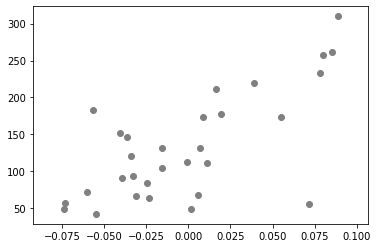

```python
plt.scatter(diabetes_X_test,diabetes_y_test,color ='grey')
```

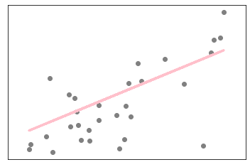

```python
plt.scatter(diabetes_X_test,diabetes_y_test,color ='grey')
plt.plot(diabetes_X_test,diabetes_y_pred,color='pink',linewidth=3)
plt.xticks(())
plt.yticks(())
plt.show()
```

# Decision Tree Regressor

Decision tree can be used for the regression problems. Decision tree build the regression model in the form of tree structure. Decision tree regression model is selected for modeling and predicting the data. Decision tree regression model can be used for large set of data.

We can use the fit(X,y) method to train the model. Here, X is a 2D array. In it the rows specifies the instances and columns specifies the corresponding features. y is the 1D array which provides the target output for each instance in X. After the model is trained, we can call a predict(D) to make the predictions on new data D. In that case, we do not need to provide the target outputs y. we can let the tree making the predictions and will then check the accuracy of those predictions.

```python
from sklearn import tree
from sklearn.model_selection import cross_val_score, KFold, train_test_split
from sklearn.tree import DecisionTreeRegressor
#Defining the decision tree
X=diabetes_X_train
y=diabetes_y_train
```

Training decision tree with its default parameter.

```python
default_tree = DecisionTreeRegressor()
default_tree.fit(diabetes_X_train,diabetes_y_train)
predictions = default_tree.predict(diabetes_X_test)
```

```python
Score_Test=default_tree.score(diabetes_X_test,diabetes_y_test)
```

```python
print(Score_Test)
```

```
-0.12103643052394042
```

```python
from sklearn.model_selection import cross_val_score, KFold
num_folds=10
kf = KFold(n_splits=num_folds, shuffle=True)
scores1 = cross_val_score(default_tree, X, y,cv=kf,scoring='neg_mean_squared_error')
```

Parameter Optimization

We need to optimize the decision tree model with its best parameter for the best accuracy in testing data. To find the best value for parameter d i.e. depth of tree, Training set is divided to two sets Training set and validation set. The model is trained in testing set and validated using validation set. For different values of d, we evaluate the validation error. For the value of d, that gives the minimum validation error determined the expected best value for parameter d i.e max_depth.

```python
X
```

[output not shown]

[output cut: 357 more lines]

[output not shown]

```python
#Splitting test set to testing and validation set
#split data
XXtrain, XXval, yytrain, yyval = train_test_split(X, y, test_size=0.2, random_state=42)
```

```python
#Evaluating the scores on varying depth
#range of max depth we want to try

depth_range=[1,5,10,15,20,25,30,35,40,45,50]
#depth_Scores_train=np.zeros(len(depth_range))
#depth_Scores_val=np.zeros(len(depth_range))
depth_dScores_train=[]
depth_dScores_val=[]
depth_dScores_test=[]


for d in depth_range:
    regressor = DecisionTreeRegressor(max_depth=d)
    regressor.fit(XXtrain,yytrain)

    scores_train = regressor.score(XXtrain,yytrain)
    depth_dScores_train.append(scores_train)

    scores_val = regressor.score(XXval,yyval)
    depth_dScores_val.append(scores_val)

    scores_test = regressor.score(diabetes_X_test,diabetes_y_test)
    depth_dScores_test.append(scores_test)
    print('Depth')
    print(d)

#print(depth_Scores)
```

```
Depth
1
Depth
5
Depth
10
Depth
15
Depth
20
Depth
25
Depth
30
Depth
35
Depth
40
Depth
45
Depth
50
```

Complexity Curves

```python
dtrain= [1.0-x for x in depth_dScores_train]
dval= [1.0-x for x in depth_dScores_val]

dtest= [1.0-x for x in depth_dScores_test]
```

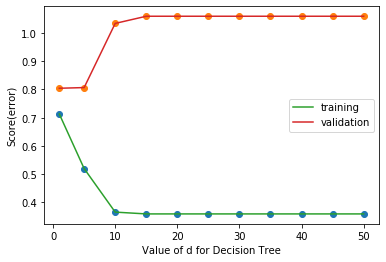

```python
# plot how error scores changes as we vary depth
import matplotlib.pyplot as plt
%matplotlib inline

plt.plot(depth_range,dtrain ,'o')
plt.plot(depth_range, dval,'o')
plt.plot(depth_range, dtrain,label='training')
plt.plot(depth_range, dval,label='validation')


plt.xlabel('Value of d for Decision Tree')
plt.ylabel('Score(error)')
plt.legend(loc='best')
plt.savefig('complexitycurve.png')
```

Analysing model performance

The performance of model is analysed based on the best parameter setting for both training and testing data for varying number of samples.

```python
#learning curve
num_samples=np.arange(1,len(y))
print(len(num_samples))

depth_Scores_train=np.zeros(len(num_samples))
depth_Scores_val=np.zeros(len(num_samples))
#depth_Scores_test=np.zeros(len(num_samples))

for idx, samples in enumerate(num_samples):
    regressor = DecisionTreeRegressor(max_depth=20)

    regressor.fit(XXtrain[0:samples, :],yytrain[0:samples])

    depth_Scores_train[idx]=regressor.score(XXtrain[0:samples, :],yytrain[0:samples])
    depth_Scores_val[idx]=regressor.score(XXval[0:samples, :],yyval[0:samples])

    #depth_Scores_test[idx]=regressor.score(X_test,y_test)
    print('samples')
    print(samples)
```

[output not shown]

[output cut: 175 more lines]

[output not shown]

[output not shown]

[output cut: 538 more lines]

[output not shown]

```python
#Calculating expected srror score
ltrain= [1.0-x for x in depth_Scores_train]
lval= [1.0-x for x in depth_Scores_val]
```

# Plotting learning curve

Model is trained on training data set. The learning curve plot the error for both training set and the error on the validation set. By comparing both the curve we can diagonose bias and variance problem. From the plot , we can see that the error on the training set is low whereas the error on the validation set is high. In this case, model suffer form high variance problem.

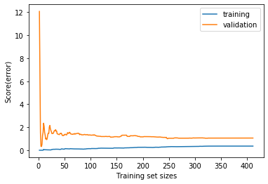

```python
import matplotlib.pyplot as plt
%matplotlib inline

plt.plot(num_samples, ltrain,label='training')
plt.plot(num_samples, lval,label='validation')

#plt.plot(num_samples, ltest,label='testing')
plt.xlabel('Training set sizes')
plt.ylabel('Score(error)')
plt.legend(loc='best')
plt.savefig('Learning curve_decisiontree.png')
```

When using a simple training and test set split to select a model, the test set error may give an overly optimistic estimate of the model's performance, because the parameters were selected for best performance on the test set. Because of this, the common approach is to use a split with 3 sets: training set, validation set, and test set.

Cross-validation :- Splittng the data into 3 parts can reduce the amount of data available for training the model and also the estimated performance can vary a lot over the different training and validation splits. One possible solution for these problems is the K-fold cross-validation procedure. It consists of dividing a data set in K parts rather than using the fixed split of training and validation data. it consists of dividing a data set in K parts, K − 1 of which are used for training and one of them used for validation. The process is repeated K times, and every time a different part of the data set for the validation is used.

```python
import matplotlib.pylab as plt
from sklearn import tree
from sklearn.model_selection import cross_val_score, KFold, train_test_split

%matplotlib inline


num_folds=10
kf = KFold(n_splits=num_folds, shuffle=True)
dt1 = tree.DecisionTreeRegressor(max_depth=1)
dt2 = tree.DecisionTreeRegressor(max_depth=20)

scores1 = cross_val_score(dt1, XXtrain, yytrain,cv=kf,scoring='neg_mean_squared_error')
scores2 = cross_val_score(dt2, XXtrain, yytrain,cv=kf,scoring='neg_mean_squared_error')

print("cross validation scores:")

print("mean error tree 1:" + repr(np.mean(scores1)))
print("mean error tree 2:" + repr(np.mean(scores2)))

delta_mean = np.mean(scores1-scores2)
print("mean error difference:" +repr(delta_mean))

sdelta =np.sqrt(1./(num_folds*(num_folds-1))*np.sum(((scores1-scores2)-delta_mean)**2))

print("error stdev estimate:" +repr(sdelta))
print("CI interval: [" +repr(delta_mean- 2.23* sdelta)
      +","+repr(delta_mean+ 2.23* sdelta) +"]")
```

```
cross validation scores:
mean error tree 1:-4550.948326362378
mean error tree 2:-6188.185711253156
mean error difference:1637.2373848907782
error stdev estimate:529.2309181077009
CI interval: [457.0524375106054,2817.4223322709513]
```

# Multilayer Perceptron

Data preprocessing :- If the data is not normalized, the neural network may have difficulty in converging before the maximum number of iterations allowed. There is a need to scale the data because the Multi-layer Perceptron is sensitive to the feature scaling. We must apply the same scaling to the test set.

For multilayer perceptron, data is very sensitive. So, we need to first scale it. we can get zero means and unit variance for each column in the data set.

```python
diabetes_y_train
```

[output not shown]

Now, we can train our model. After we have a model it can be used to get the predictions. We can do this by the predict() method.

```python
from sklearn.preprocessing import StandardScaler
scaler = StandardScaler()
#plot data
# Fit only to the training data
scaler.fit(diabetes_X_train)
# Now apply the transformations to the data:
diabetes_X_train = scaler.transform(diabetes_X_train)
diabetes_X_test = scaler.transform(diabetes_X_test)



#diabetes_y_train = scaler.transform(diabetes_y_train)
#diabetes_y_test = scaler.transform(diabetes_y_test)
```

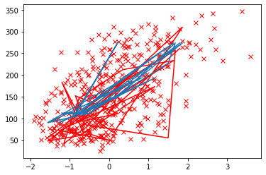

```python
from sklearn.neural_network import MLPRegressor as mlp
net = mlp(hidden_layer_sizes=(50,), activation='tanh', solver='lbfgs', max_iter=2000)
net.fit(diabetes_X_train,diabetes_y_train)
p = net.predict(diabetes_X_test)
#plot training data
plt.plot(diabetes_X_train,diabetes_y_train,'rx')
plt.plot(diabetes_X_test,diabetes_y_test,'r')
#plot target function
plt.plot(diabetes_X_test,p)
```

Now, The different hidden layers with the sizes in 1-50 have tried. For each setting, the network score is obtained on the test set and the results is plotted.

```
[-0.07923513  0.41647587  0.40590748  0.39746817  0.33192937  0.38490881
  0.38820128  0.37653569  0.33957251  0.49410482  0.37203761  0.35224591] [-1.11022302e-15  3.39004651e-01  3.41716215e-01  3.49446164e-01
  3.67791853e-01  3.63698836e-01  3.82123921e-01  3.89187833e-01
  3.68858178e-01  3.81473238e-01  3.80784385e-01  4.12373815e-01]
```

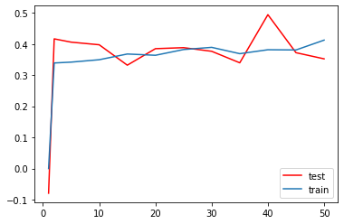

```python
import matplotlib.pyplot as pl
from sklearn.neural_network import MLPRegressor as mlp
numh = [1,2,5,10,15,20,25,30,35,40,45,50]
#numh = [1,2,5]
restest = np.zeros(len(numh))
restrain = np.zeros(len(numh))

ind=0
#ideally you would run this multiple times and report average results
#(or use cross-validation, see later)
for h in numh:
    net = mlp(hidden_layer_sizes=(h,), activation='tanh', solver='lbfgs', max_iter=2000)
    net.fit(diabetes_X_train,diabetes_y_train)
    restest[ind] += net.score(diabetes_X_test,diabetes_y_test)
    restrain[ind] += net.score(diabetes_X_train,diabetes_y_train)
    ind +=1

print(restest, restrain)
#plot performance
pl.figure()
pl.plot(numh,restest,'r',label='test')
pl.plot(numh,restrain,label='train')
pl.legend()
pl.show()
```

Preventing Overfitting :-

The use of the too many hidden units will lead to the overfitting the training data. On the other hand, using too few hidden units can be a challenging task. A common way to stop the network from overfitting is to use weight decay. Weight decay can easily be implemented by adding an additional term to the cost function which penalizes large weight values. This cause the network to prefer a small or 0 weight values, limiting its representational power and thus preventing it from overfitting. Here, λ is the decay parameter which determines how much the weights are penalized.

```
[ -3519.77547373  -4263.24887296  -4542.36804871  -4788.21734603
  -3311.28132962  -4193.07260741 -13021.18074455  -4751.60533843
  -5988.38259467  -4010.7335609 ]
[ -3654.80954871  -4373.61669009  -5452.47180177  -5048.22997863
  -3065.97497021 -34199.9296184   -4193.6929754   -4495.20344189
  -3920.34480967  -4525.52052419]
[ -3912.63678447  -4005.01407106  -4564.67214901  -4730.93122784
  -3228.29161995  -4075.43934906  -4891.06797822  -4575.82949277
 -22808.80602025  -4366.42879122]
[-3980.48472679 -4436.02007361 -4705.71974962 -5019.13509527
 -3023.51416126 -4734.27634418 -3940.37448877 -4539.28395379
 -3695.58635337 -4015.48691112]
[-3844.56400107 -4464.75799388 -4710.69858314 -5421.18462371
 -3548.84362591 -4002.13394862 -4186.44456559 -4537.56808619
 -4591.94266178 -4332.65664683]
[-3898.25743732 -4001.33628729 -4400.22669874 -4585.08747398
 -3109.82244563 -4334.83293514 -4096.08642738 -4781.58909017
 -4048.00141854 -4322.62498307]
[-4034.16881003 -3923.17903256 -4334.27527696 -4277.41044953
 -3031.0102938  -4017.56248181 -3970.41076342 -4533.01583227
 -3781.07237918 -4202.01840271]
```

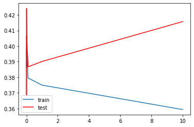

```python
import numpy as np
from sklearn.neural_network import MLPRegressor as mlp

decays=[0,0.0001,0.001,0.01,0.1,1,10]
#decays=[0,0.0001]
restest = np.zeros(len(decays))
restrain = np.zeros(len(decays))
from sklearn.model_selection import cross_val_score

ind=0
for l in decays:
    net = mlp(hidden_layer_sizes=(50,), activation='tanh',
              alpha = l, solver='lbfgs', max_iter=2000)
    scores = cross_val_score(net, diabetes_X_train, diabetes_y_train,
                             cv=10,scoring='neg_mean_squared_error')
    print(scores)
    net.fit(diabetes_X_train,diabetes_y_train)
    restest[ind] += net.score(diabetes_X_test,diabetes_y_test)
    restrain[ind] += net.score(diabetes_X_train,diabetes_y_train)
    ind+=1

#plot performance
pl.figure()
pl.plot(decays,restrain,label='train')
pl.plot(decays,restest,'r',label='test')
pl.legend()
pl.show()
```

When using a simple training and test set split to select a model, the test set error may give an overly optimistic estimate of the model's performance, because the parameters were selected for best performance on the test set. Because of this, the common approach is to use a split with 3 sets: training set, validation set, and test set.

Cross-validation :- Splittng the data into 3 parts can reduce the amount of data available for training the model and also the estimated performance can vary a lot over the different training and validation splits. One possible solution for these problems is the K-fold cross-validation procedure. It consists of dividing a data set in K parts rather than using the fixed split of training and validation data. it consists of dividing a data set in K parts, K − 1 of which are used for training and one of them used for validation. The process is repeated K times, and every time a different part of the data set for the validation is used.

```python
import matplotlib.pylab as plt
from sklearn import tree
from sklearn.model_selection import cross_val_score, KFold, train_test_split
from sklearn.datasets import load_boston
%matplotlib inline


num_folds=10
kf = KFold(n_splits=num_folds, shuffle=True)
dt1 = tree.DecisionTreeRegressor(max_depth=1)
dt2 = tree.DecisionTreeRegressor(max_depth=20)

scores1 = cross_val_score(dt1, diabetes_X_train, diabetes_y_train,cv=kf,scoring='neg_mean_squared_error')
scores2 = cross_val_score(dt2, diabetes_X_train, diabetes_y_train,cv=kf,scoring='neg_mean_squared_error')

print("cross validation scores:")

print("mean error tree 1:" + repr(np.mean(scores1)))
print("mean error tree 2:" + repr(np.mean(scores2)))

delta_mean = np.mean(scores1-scores2)
print("mean error difference:" +repr(delta_mean))

sdelta =np.sqrt(1./(num_folds*(num_folds-1))*np.sum(((scores1-scores2)-delta_mean)**2))

print("error stdev estimate:" +repr(sdelta))
print("CI interval: [" +repr(delta_mean- 2.23* sdelta)
      +","+repr(delta_mean+ 2.23* sdelta) +"]")
```

```
cross validation scores:
mean error tree 1:-4583.103742184154
mean error tree 2:-5806.469024180538
mean error difference:1223.3652819963859
error stdev estimate:514.1151665822304
CI interval: [76.88846051801215,2369.84210347476]
```

Diagnosing high bias/variance problems:

Two possible problems with the trained model are high bias and high variance. High bias models cannot represent the target hypothesis well which leads to the high error rate. On the other hand, High variance models tends to overfit the training data which results in the poor generalization. Learning curves are an easy way of determining whether a model is suffering from high bias or high variance. Learning curves plot the errors on the training set and the error on a validation set which is an estimate for generalization error for different sizes of training sets such as using 50, 100, 150, 200,.. samples for training.

Training the decision tree with max_depth=1 and with sample size 200 is as follows :-

```python
diabetes_X_train, diabetes_X_val, diabetes_y_train, diabetes_y_val = train_test_split(diabetes_X_train ,diabetes_y_train)
```

Training the decision tree with max_depth=1 and with sample size 200 is as follows :-

```
Training scores:

 [       nan 1.         0.9980315  0.97442249 0.84043124 0.86351685
 0.64549494 0.56916088 0.53102144 0.55250398 0.38836618 0.40351155
 0.42100983 0.39174315 0.3405627  0.34884683 0.37610347 0.36567804
 0.38646496 0.40319714 0.41782892 0.33721916 0.33513736 0.33350243
 0.37505787 0.3721107  0.3852063  0.39534984 0.42276488 0.38383665
 0.40936589 0.43727333 0.44545088 0.40114081 0.41040543 0.34878747
 0.34687117 0.35494631 0.33873335 0.33205429 0.3158269  0.32197596
 0.31157767 0.31728587 0.31408697 0.34927212 0.35429291 0.32533783
 0.33884133 0.34089811 0.3119615  0.31393431 0.32393979 0.3246181
 0.325016   0.32811081 0.34387646 0.34816362 0.36581438 0.35533495
 0.35949198 0.36287438 0.37186232 0.36962349 0.3655515  0.367126
 0.36742674 0.36949192 0.33508602 0.33642678 0.32224857 0.32286334
 0.31742737 0.32052317 0.31608884 0.31373553 0.31688982 0.31085717
 0.31301601 0.31528787 0.31687991 0.30149928 0.30256677 0.30075871
 0.30409354 0.3047622  0.30658987 0.30744336 0.3124965  0.29908776
 0.30324242 0.3048953  0.30484145 0.31024253 0.28441205 0.28642808
 0.26833384 0.27748616 0.27709387 0.27900185 0.2808077  0.26445291
 0.26524978 0.2567605  0.25735272 0.25889311 0.25909634 0.25893301
 0.27370339 0.27519255 0.27285435 0.26332659 0.2648681  0.26619629
 0.25847718 0.25897055 0.2372327  0.23683299 0.23837094 0.23736618
 0.23494505 0.2389323  0.23838225 0.22928853 0.21857473 0.22415874
 0.21203804 0.21310908 0.21665141 0.21380751 0.20887594 0.21264281
 0.21449209 0.21147799 0.21419338 0.21096491 0.20575115 0.21225539
 0.21716909 0.21211624 0.21234574 0.21711734 0.21858955 0.22105152
 0.22669926 0.23035271 0.22536888 0.22220006 0.21379353 0.20370327
 0.20163927 0.20664097 0.20880521 0.21242041 0.21346778 0.21667542
 0.22087915 0.22350999 0.22876653 0.23106934 0.22847612 0.231789
 0.22193657 0.21772969 0.22404482 0.22730789 0.22985882 0.23135513
 0.2371857  0.2357998  0.23601438 0.23852625 0.2439808  0.24487808
 0.24546431 0.24127904 0.24312836 0.24035864 0.24301295 0.24502174
 0.24789062 0.25041662 0.24762448 0.2504819  0.25241617 0.25513064
 0.2571316  0.25432052 0.24986602 0.24924496 0.25068285 0.25216772
 0.25701472 0.25864877 0.26101507 0.26284488 0.26506637 0.26738115
 0.26912412]

 ----------------------------------------------------------------------

Validation scores:
```

[output cut: 36 more lines]

```
  2.78704574e-01  2.79342588e-01  2.79333681e-01  2.79998238e-01
  2.80763746e-01  2.82114724e-01  2.80566802e-01  2.79306382e-01
  2.78252720e-01  2.75108072e-01  2.73908248e-01  2.74599709e-01
  2.75357887e-01  2.77380348e-01  2.77488516e-01  2.78933243e-01
  2.79351232e-01  2.80251804e-01  2.80787002e-01  2.81446643e-01
  2.80413239e-01  2.81928291e-01  2.74439337e-01  2.72867767e-01
  2.73205065e-01  2.74811138e-01  2.75690886e-01  2.75984040e-01
  2.75886607e-01  2.75953253e-01  2.75747212e-01  2.75720005e-01
  2.75436790e-01  2.75469774e-01  2.75516139e-01  2.74083394e-01
  2.74573481e-01  2.73438587e-01  2.74510617e-01  2.75095649e-01
  2.76326627e-01  2.77165237e-01  2.76241974e-01  2.77519803e-01
  2.77980420e-01  2.78951834e-01  2.79380908e-01  2.78669123e-01
  2.78878383e-01  2.78927198e-01  2.79160625e-01  2.79405671e-01
  2.79241416e-01  2.79527701e-01  2.80131113e-01  2.80448993e-01
  2.80904584e-01  2.81369311e-01  2.81589017e-01]
```

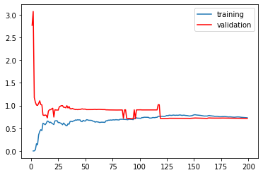

```python
from sklearn import tree
num_samples = np.arange(1,200)
depth=1
trainscore = np.zeros(len(num_samples))
valscore = np.zeros(len(num_samples))
for idx,samples in enumerate(num_samples):
    model = tree.DecisionTreeRegressor(max_depth=depth)
    model.fit(diabetes_X_train[0:samples,:],diabetes_y_train[0:samples])
    trainscore[idx] = model.score(diabetes_X_train[0:samples,:],diabetes_y_train[0:samples])
    valscore[idx] = model.score(diabetes_X_val,diabetes_y_val)
print('Training scores:\n\n', trainscore)
print('\n', '-' * 70) # separator to make the output easy to read
print('\nValidation scores:\n\n', valscore)
plt.figure()
#plt.ylim((-0.1,0.5))
#error rate = 1.0 - accurracy
plt.plot(num_samples,1.0-trainscore,label='training')
plt.plot(num_samples,1.0-valscore,'r',label='validation')
plt.legend()
```

The error on the training set and the validation sets are typically close, and both they are high. The model is suffering from a high bias.

Training the decision tree with max_depth = 20 and sample size 200 is as follows :-

```
Training scores:

 [       nan 1.         1.         1.         1.         1.
 1.         1.         1.         0.9699892  0.97037729 0.97749006
 0.98096084 0.98104295 0.98104524 0.98135863 0.98288598 0.98294094
 0.98372215 0.98429676 0.98520586 0.98630403 0.98632217 0.95784244
 0.96435871 0.96440476 0.96568492 0.96645088 0.9683653  0.96891107
 0.97058367 0.97306695 0.9752631  0.97583802 0.96216039 0.9642009
 0.95721385 0.95894962 0.9576406  0.94128062 0.94174174 0.94278821
 0.94298573 0.94516964 0.94517134 0.95032186 0.9520348  0.95210705
 0.95308583 0.94401588 0.94552636 0.9456837  0.94647588 0.94302151
 0.94308086 0.94339874 0.94487804 0.94551401 0.94733332 0.94754015
 0.94816011 0.94510023 0.94587478 0.92719079 0.92721021 0.9257873
 0.92585533 0.92177994 0.90408089 0.89565006 0.8968094  0.88693235
 0.88452895 0.88684982 0.87405722 0.87407115 0.87570082 0.87272519
 0.86664843 0.86732462 0.87118922 0.87330219 0.86792345 0.86793543
 0.86995965 0.86382456 0.86687264 0.87047876 0.87196426 0.85515823
 0.83347277 0.8362774  0.82816504 0.82968019 0.83294928 0.83438509
 0.82601766 0.82821904 0.82003043 0.82216574 0.82328016 0.82782826
 0.82791474 0.82968369 0.82982251 0.83241367 0.83246866 0.82674686
 0.82977474 0.83051652 0.83066674 0.81501356 0.81567737 0.81268095
 0.81450091 0.81462672 0.8167286  0.81673023 0.82287769 0.82288355
 0.82291474 0.79806965 0.79816964 0.79879311 0.79968334 0.80201997
 0.7977627  0.79453451 0.7964902  0.78559756 0.78576079 0.78678145
 0.78692782 0.7862262  0.7873899  0.78741858 0.77792224 0.78217147
 0.77627145 0.77681701 0.77697479 0.77663353 0.76408259 0.75788689
 0.76165532 0.76355401 0.76156159 0.76164673 0.75923698 0.75653946
 0.74449141 0.74754663 0.7485188  0.75195847 0.75146227 0.7539141
 0.75593504 0.75342229 0.75576861 0.75688177 0.75699972 0.74908759
 0.72191338 0.7117411  0.7221437  0.71600016 0.71366324 0.71407103
 0.72023221 0.72024115 0.72014874 0.71959992 0.72509785 0.72542526
 0.72568972 0.72616325 0.72705285 0.72720047 0.729202   0.72498681
 0.72782238 0.72971439 0.72422869 0.71118922 0.71232465 0.70691217
 0.70819217 0.70257455 0.70172892 0.70173984 0.70217399 0.70246563
 0.69839812 0.69760811 0.69974702 0.69302299 0.69499664 0.6929145
 0.6885227 ]

 ----------------------------------------------------------------------

Validation scores:
```

[output cut: 20 more lines]

```
 -0.20738889 -0.20531658 -0.20531658 -0.2062164  -0.2062164  -0.20216722
 -0.20271938 -0.14917078 -0.11631375 -0.08502459 -0.08436847 -0.08436847
 -0.0996831  -0.0996831  -0.09808967 -0.09808967 -0.09808967 -0.09946155
 -0.09655929 -0.09655929 -0.09655929 -0.10433046 -0.10433046 -0.09827543
 -0.09827543 -0.09830781 -0.09830781 -0.09830781 -0.03033057 -0.03916525
 -0.03916525 -0.03026932 -0.03026932 -0.03193347 -0.03193347 -0.05404039
 -0.03750687 -0.083338   -0.083338   -0.083338   -0.083338   -0.08352887
 -0.08641919 -0.0842719  -0.0842719  -0.0842719  -0.10214558 -0.10214558
 -0.09562231 -0.10336621 -0.10336621 -0.12874898 -0.12565254 -0.12356584
 -0.12356584 -0.12356584 -0.12356584 -0.12356584 -0.14965378 -0.14965378
 -0.14652486 -0.15775215 -0.15775215 -0.15900175 -0.15900175 -0.1619824
 -0.15879214 -0.15879214 -0.15879214 -0.13948967 -0.13940295 -0.15303498
 -0.15379847 -0.1523925  -0.15620991 -0.15413079 -0.15493891 -0.15493891
 -0.14497273 -0.13718112 -0.13718112 -0.11777366 -0.11777366 -0.11777366
 -0.08464907]
```

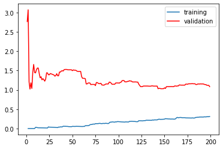

```python
num_samples = np.arange(1,200)
depth=20
train_score1 = np.zeros(len(num_samples))
val_score1 = np.zeros(len(num_samples))
for idx,samples in enumerate(num_samples):
    model = tree.DecisionTreeRegressor(max_depth=depth)
    model.fit(diabetes_X_train[0:samples,:],diabetes_y_train[0:samples])
    train_score1[idx] = model.score(diabetes_X_train[0:samples,:],diabetes_y_train[0:samples])
    val_score1[idx] = model.score(diabetes_X_val,diabetes_y_val)
print('Training scores:\n\n', train_score1)
print('\n', '-' * 70)
print('\nValidation scores:\n\n', val_score1)
plt.figure()
#plt.ylim((-0.1,0.5))
#error rate = 1.0 - accurracy
plt.plot(num_samples,1.0-train_score1,label='training')
plt.plot(num_samples,1.0-val_score1,'r',label='validation')
plt.legend()
```

In this case, the training set error is lower and the validation set error is much higher. The model is suffering from high variance.

Trying the values for tree depth in the range 1-40 and plotting the validation and training error for these values.

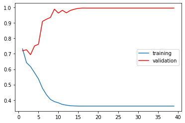

```python
from sklearn import metrics
from sklearn.tree import DecisionTreeRegressor

max_d = np.arange(1,40)

train_score = np.zeros(len(max_d))
val_score = np.zeros(len(max_d))


for idx,depth in enumerate(max_d):
    model = DecisionTreeRegressor(max_depth=depth)
    model.fit(diabetes_X_train,diabetes_y_train)
    train_score[idx] = model.score(diabetes_X_train,diabetes_y_train)
    val_score[idx] = model.score(diabetes_X_val,diabetes_y_val)


plt.figure()
plt.plot(max_d,1.0-train_score,label='training')
plt.plot(max_d,1.0-val_score,'r',label='validation')


plt.legend()
```

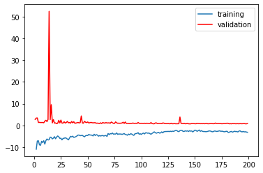

```python
# Bias and variance For neural network model with sample size 200
import numpy as np
import matplotlib.pyplot as pl
from sklearn.neural_network import MLPRegressor as mlp

num_samples = np.arange(1,200)

train_scoren = np.zeros(len(num_samples))
val_scoren = np.zeros(len(num_samples))
numh = [1,2,5,10,15,20,25,30,35,40,45,50]
#numh = [1,2,5]

ind=0
#ideally you would run this multiple times and report average results
#(or use cross-validation, see later)
for idx,samples in enumerate(num_samples):
    for h in numh:
        net = mlp(hidden_layer_sizes=(h,), activation='tanh', solver='lbfgs', max_iter=1000)
        net.fit(diabetes_X_train[0:samples,:],diabetes_y_train[0:samples])
        train_scoren[idx] += net.score(diabetes_X_train[0:samples,:],diabetes_y_train[0:samples])
        val_scoren[idx] = net.score(diabetes_X_val,diabetes_y_val)
        ind +=1



#plot performance
pl.figure()
plt.plot(num_samples,1.0-train_scoren,label='training')
plt.plot(num_samples,1.0-val_scoren,'r',label='validation')
pl.legend()
pl.show()
```

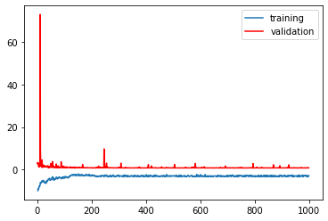

```python
#  neural network model with sample size 1000
import numpy as np
import matplotlib.pyplot as pl
from sklearn.neural_network import MLPRegressor as mlp

num_samples = np.arange(1,1000)

train_scoren = np.zeros(len(num_samples))
val_scoren = np.zeros(len(num_samples))
numh = [1,2,5,10,15,20,25,30,35,40,45,50]
#numh = [1,2,5]

ind=0
#ideally you would run this multiple times and report average results
#(or use cross-validation, see later)
for idx,samples in enumerate(num_samples):
    for h in numh:
        net = mlp(hidden_layer_sizes=(h,), activation='tanh', solver='lbfgs', max_iter=1000)
        net.fit(diabetes_X_train[0:samples,:],diabetes_y_train[0:samples])
        train_scoren[idx] += net.score(diabetes_X_train[0:samples,:],diabetes_y_train[0:samples])
        val_scoren[idx] = net.score(diabetes_X_val,diabetes_y_val)
        ind +=1



#plot performance
pl.figure()
plt.plot(num_samples,1.0-train_scoren,label='training')
plt.plot(num_samples,1.0-val_scoren,'r',label='validation')
pl.legend()
pl.show()
```

Estimating errors on unseen data

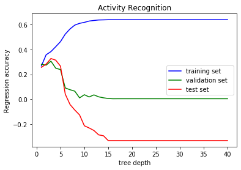

```python
# Decision tree

from sklearn.tree import DecisionTreeRegressor
import pylab as pl
training_errors = np.zeros(40)
test_errors = np.zeros(40)
vali_errors = np.zeros(40)


for d in range(1,41):
    tree = DecisionTreeRegressor(max_depth=d)
    tree.fit(diabetes_X_train,diabetes_y_train)
    training_errors[d-1] = tree.score(diabetes_X_train,diabetes_y_train)

    vali_errors[d-1] = tree.score(diabetes_X_val,diabetes_y_val)
    test_errors[d-1] = tree.score(diabetes_X_test,diabetes_y_test)

pl.figure()
pl.plot(np.arange(1,41),training_errors,c='b',label='training set  ')

pl.plot(np.arange(1,41),vali_errors,c='g',label='validation set  ')
pl.plot(np.arange(1,41),test_errors,c='r',label='test set  ')
pl.xlabel("tree depth")
pl.ylabel("Regression accuracy")
pl.title("Activity Recognition")
pl.legend()
pl.show()
```

In this case, from the depth 15, the accuracy on the training set and validation set is constant.

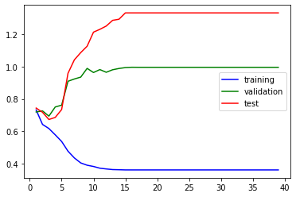

```python
from sklearn import metrics
from sklearn.tree import DecisionTreeRegressor

max_d = np.arange(1,40)

train_score = np.zeros(len(max_d))
val_score = np.zeros(len(max_d))
test_score = np.zeros(len(max_d))


for idx,depth in enumerate(max_d):
    model = DecisionTreeRegressor(max_depth=depth)
    model.fit(diabetes_X_train,diabetes_y_train)
    train_score[idx] = model.score(diabetes_X_train,diabetes_y_train)

    test_score[idx] = model.score(diabetes_X_test,diabetes_y_test)
    val_score[idx] = model.score(diabetes_X_val,diabetes_y_val)


plt.figure()
plt.plot(max_d,1.0-train_score,'b',label='training')
plt.plot(max_d,1.0-val_score,'g',label='validation')

plt.plot(max_d,1.0-test_score,'r',label='test')


plt.legend()
```

In this case, from the depth 15, the accuracy on the training set and validation set is constant.

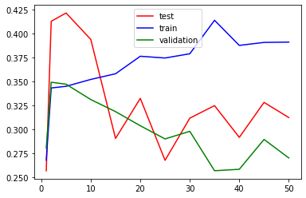

```python
# For Artificial neural network


import matplotlib.pyplot as pl
import numpy as np
from sklearn.neural_network import MLPRegressor as mlp
numh = [1,2,5,10,15,20,25,30,35,40,45,50]
#numh = [1,2,5]
restest = np.zeros(len(numh))
restrain = np.zeros(len(numh))
resval = np.zeros(len(numh))

ind=0
#ideally you would run this multiple times and report average results
#(or use cross-validation, see later)
for h in numh:
    net = mlp(hidden_layer_sizes=(h,), activation='tanh', solver='lbfgs', max_iter=2000)
    net.fit(diabetes_X_train,diabetes_y_train)

    restrain[ind] += net.score(diabetes_X_train,diabetes_y_train)
    restest[ind] += net.score(diabetes_X_test,diabetes_y_test)
    resval[ind] += net.score(diabetes_X_val,diabetes_y_val)
    ind +=1



pl.figure()
pl.plot(numh,restest,'r',label='test')
pl.plot(numh,restrain,'b',label='train')
pl.plot(numh,resval,'g',label='validation')
pl.legend()
pl.show()
```

Compare Models

Two models decision tree and mlp is compared with their best parameter setting.

```python
tree = DecisionTreeRegressor(max_depth=20)
tree.fit(XXtrain,yytrain)
```

```
DecisionTreeRegressor(criterion='mse', max_depth=20, max_features=None,
                      max_leaf_nodes=None, min_impurity_decrease=0.0,
                      min_impurity_split=None, min_samples_leaf=1,
                      min_samples_split=2, min_weight_fraction_leaf=0.0,
                      presort=False, random_state=None, splitter='best')
```

```python
mlp_model = mlp(hidden_layer_sizes=(50,), alpha=0.1,activation='tanh', solver='lbfgs', max_iter=2000)
mlp_model.fit(diabetes_X_train,diabetes_y_train)
```

```
MLPRegressor(activation='tanh', alpha=0.1, batch_size='auto', beta_1=0.9,
             beta_2=0.999, early_stopping=False, epsilon=1e-08,
             hidden_layer_sizes=(50,), learning_rate='constant',
             learning_rate_init=0.001, max_iter=2000, momentum=0.9,
             n_iter_no_change=10, nesterovs_momentum=True, power_t=0.5,
             random_state=None, shuffle=True, solver='lbfgs', tol=0.0001,
             validation_fraction=0.1, verbose=False, warm_start=False)
```

```python
from sklearn.externals import joblib
# Save the model as a pickle in a file
joblib.dump(tree, 'tree_model.pkl')

# Save the model as a pickle in a file
joblib.dump(mlp_model, 'mlp_model.pkl')
```

```
['mlp_model.pkl']
```

```python
model1 = joblib.load('tree_model.pkl')
model2 = joblib.load('mlp_model.pkl')
```

Test score of both models:

```python
print(model2.score(diabetes_X_train,diabetes_y_train))
```

```
0.38754042605110484
```

```python
print(model1.score(diabetes_X_test,diabetes_y_test))
print(model2.score(diabetes_X_test,diabetes_y_test))
```

```
-0.060782654433728434
0.31537916291904944
```

Visualizing the predicted and actual y

```python
predicted_y_mlp=model2.predict(diabetes_X_test)
actual_y_mlp=diabetes_y_test
y_predicted_inverse = scaler.inverse_transform(predicted_y_mlp)
y_actual_inverse = scaler.inverse_transform(actual_y_mlp)
```

```python
predicted_y_tree=model1.predict(diabetes_X_test)
```

Plotting the predicted y with actual output for both the models

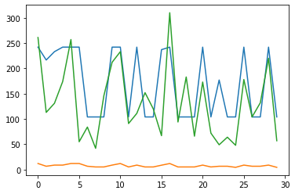

```python
plt.plot(predicted_y_tree)
plt.plot(y_predicted_inverse)
plt.plot(diabetes_y_test)
```

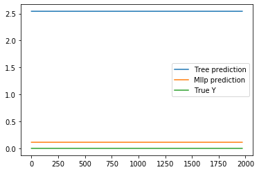

```python
def moving_average(x, w):
    return np.convolve(x, np.ones(w), 'valid') / w

tree_predict_y=predicted_y_tree
tree_predict_y.ravel()

tree_predict_y=moving_average(tree_predict_y, 2000)

mlp_predict_y=y_predicted_inverse
mlp_predict_y.ravel()

mlp_predict_y=moving_average(mlp_predict_y, 2000)

actual_value_y=diabetes_X_test
actual_value_y=actual_value_y[:, 0]

actual_value_y=moving_average(actual_value_y, 2000)


plt.plot(tree_predict_y,label='Tree prediction')
plt.plot(mlp_predict_y,label='Mllp prediction')
plt.plot(actual_value_y,label='True Y')
plt.legend()
```

Solving Overfitting Problem(Boosting methods):

```python
from sklearn.ensemble import GradientBoostingRegressor
ensemble_decision= GradientBoostingRegressor()
ensemble_decision.fit(diabetes_X_train, diabetes_X_train)
ensemble_decision.score(diabetes_X_test,diabetes_y_test)
```

```
-3.43132663143823
```

```python
ensemble_decision.score(diabetes_X_train,diabetes_X_train)
```

```
0.9999784833518661
```

```python
depths=[1,10,20,30,40]

score_boost_train=[]
score_boost_val=[]

for d in depths:
    est= GradientBoostingRegressor( max_depth=d)
    est.fit(diabetes_X_train, diabetes_y_train)
    score1=est.score(diabetes_X_train,diabetes_y_train)
    score2=est.score(diabetes_X_val,diabetes_y_val)
    score_boost_train.append(score1)
    score_boost_val.append(score2)
```

```python
print(score_boost_val)
```

```
[0.3106297667775054, 0.006381926817983663, 0.0042678869260006635, 0.0042678869260006635, 0.0042678869260006635]
```

Solving underfitting problem:

```python
mlp_model2 = mlp(hidden_layer_sizes=(100,), alpha=0.1,activation='tanh', solver='lbfgs', max_iter=2000)
mlp_model2.fit(diabetes_X_train,diabetes_y_train)

mlp_model2.score(diabetes_X_test,diabetes_y_test)
```

```
0.2831147705110716
```

```python
print(mlp_model2.score(diabetes_X_train,diabetes_y_train))
print(mlp_model2.score(diabetes_X_test,diabetes_y_test))
```

```
0.4180901476559896
0.2831147705110716
```

# Synthetic Data

The synthetic data can be generated as follows:

```python
import pandas as pd
import matplotlib.pyplot as plt
import numpy as np
from sklearn import datasets,linear_model
from sklearn.metrics import mean_squared_error,r2_score

from sklearn.datasets import make_regression
# generate regression dataset
x, y = make_regression(n_samples=1000, n_features=1, noise=0.75)
```

```python
x
```

[output not shown]

[output cut: 945 more lines]

[output not shown]

Splitting of data into training set and test set is as follows:

```python
from sklearn.model_selection import train_test_split
X_trainsyn, X_testsyn, y_trainsyn, y_testsyn = train_test_split(x, y, test_size = 0.20)
```

# Linear regression

Training the Linear regrssion model is as follows:

```python
regrsyn=linear_model.LinearRegression() #Linear regression object
regrsyn.fit(X_trainsyn,y_trainsyn) #Use training sets to train the model
```

```
LinearRegression(copy_X=True, fit_intercept=True, n_jobs=None, normalize=False)
```

```python
syn_y_pred=regrsyn.predict(X_testsyn) #Make predictions
regrsyn.coef_
```

```
array([31.61031049])
```

We can check the difference between the actual value and predicted value as follows:

```python
df = pd.DataFrame({'Actual': y_testsyn, 'Predicted': syn_y_pred})
df
```

|  | Actual | Predicted |
| --- | --- | --- |
| 0 | 3.563755 | 3.893708 |
| 1 | -41.063267 | -39.876388 |
| 2 | 1.858709 | 1.631721 |
| 3 | -45.572600 | -45.532893 |
| 4 | -17.205065 | -17.949395 |
| ... | ... | ... |
| 195 | 6.629653 | 6.465837 |
| 196 | 26.315739 | 26.231557 |
| 197 | 40.448342 | 40.605585 |
| 198 | -35.095671 | -35.817252 |
| 199 | -3.829900 | -3.812848 |

200 rows × 2 columns

We can plot for the comparison of Actual and Predicted values is as follows:

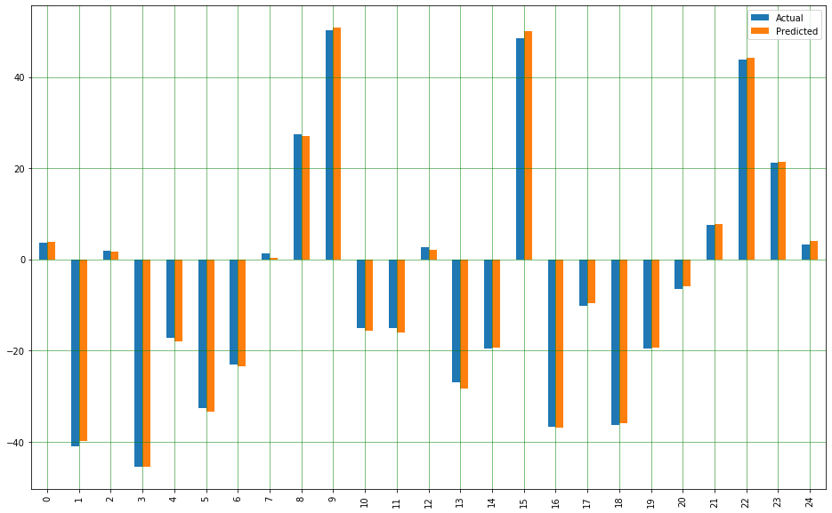

```python
df1 = df.head(25)
df1.plot(kind='bar',figsize=(16,10))
plt.grid(which='major', linestyle='-', linewidth='0.5', color='green')
plt.grid(which='minor', linestyle=':', linewidth='0.5', color='black')
plt.show()
```

```python
mean_squared_error(y_testsyn,syn_y_pred)
```

```
0.5828114007300697
```

```python
r2_score(y_testsyn,syn_y_pred) #Variance score
```

```
0.9993585879904271
```

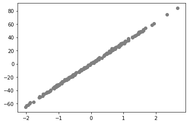

```python
plt.scatter(X_testsyn,y_testsyn,color ='grey')
```

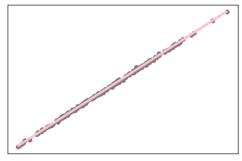

```python
plt.scatter(X_testsyn,y_testsyn,color ='grey')
plt.plot(X_testsyn,syn_y_pred,color='pink',linewidth=3)
plt.xticks(())
plt.yticks(())
plt.show()
```

# Decision Tree Regressor

Decision tree can be used for the regression problems. Decision tree build the regression model in the form of tree structure. Decision tree regression model is selected for modeling and predicting the data. Decision tree regression model can be used for large set of data.

We can use the fit(X,y) method to train the model. Here, X is a 2D array. In it the rows specifies the instances and columns specifies the corresponding features. y is the 1D array which provides the target output for each instance in X. After the model is trained, we can call a predict(D) to make the predictions on new data D. In that case, we do not need to provide the target outputs y. we can let the tree making the predictions and will then check the accuracy of those predictions.

```python
from sklearn import tree
from sklearn.model_selection import cross_val_score, KFold, train_test_split
from sklearn.tree import DecisionTreeRegressor
#Defining the decision tree
Xsyn=X_trainsyn
ysyn=y_trainsyn
```

```python
default_tree = DecisionTreeRegressor()
default_tree.fit(X_trainsyn,y_trainsyn)
```

```
DecisionTreeRegressor(criterion='mse', max_depth=None, max_features=None,
                      max_leaf_nodes=None, min_impurity_decrease=0.0,
                      min_impurity_split=None, min_samples_leaf=1,
                      min_samples_split=2, min_weight_fraction_leaf=0.0,
                      presort=False, random_state=None, splitter='best')
```

```python
ScoreTest=default_tree.score(X_testsyn,y_testsyn)
```

```python
print(ScoreTest)
```

```
0.998666847423089
```

```python
from sklearn.model_selection import cross_val_score, KFold
num_folds=10
kf = KFold(n_splits=num_folds, shuffle=True)
scores1 = cross_val_score(default_tree, Xsyn, ysyn,cv=kf,scoring='neg_mean_squared_error')
```

Parameter Optimization

We need to optimize the decision tree model with its best parameter for the best accuracy in testing data. To find the best value for parameter d i.e. depth of tree, Training set is divided to two sets Training set and validation set.The model is trained in testing set and validated using validation set. For different values of d, we evaluate the validation error. For the value of d, that gives the minimum validation error determined the expected best value for parameter d i.e max_depth.

```python
#Splitting test set to testing and validation set
#split data
XXtrainsyn, XXvalsyn, yytrainsyn, yyvalsyn = train_test_split(Xsyn, ysyn, test_size=0.2, random_state=42)
```

```python
#Evaluating the scores on varying depth
#range of max depth we want to try

depth_range=[1,5,10,15,20,25,30,35,40,45,50]
#depth_Scores_train=np.zeros(len(depth_range))
#depth_Scores_val=np.zeros(len(depth_range))
depth_dScores_train=[]
depth_dScores_val=[]
depth_dScores_test=[]


for d in depth_range:
    regressor = DecisionTreeRegressor(max_depth=d)
    regressor.fit(XXtrainsyn,yytrainsyn)

    scores_train = regressor.score(XXtrainsyn,yytrainsyn)
    depth_dScores_train.append(scores_train)

    scores_val = regressor.score(XXvalsyn,yyvalsyn)
    depth_dScores_val.append(scores_val)

    scores_test = regressor.score(X_testsyn,y_testsyn)
    depth_dScores_test.append(scores_test)
    print('Depth')
    print(d)

#print(depth_Scores)
```

```
Depth
1
Depth
5
Depth
10
Depth
15
Depth
20
Depth
25
Depth
30
Depth
35
Depth
40
Depth
45
Depth
50
```

Complexity Curves

The following graph shows the decision tree model that has been trained and validated on that training data on varying number of maximum depth. It is also known as complexity curves. There are two complexity curves one for training and one for validation. Error scores are calculated on the model . A graph is plotted that shows the maximum depth of 10 gives the best expected error.So, the best parameter setting for maximum depth is 10.

```python
#COmputing expected error

dtrain= [1.0-x for x in depth_dScores_train]
dval= [1.0-x for x in depth_dScores_val]

dtest= [1.0-x for x in depth_dScores_test]
```

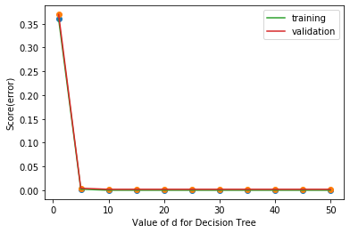

```python
# plot how error scores changes as we vary depth
import matplotlib.pyplot as plt
%matplotlib inline

plt.plot(depth_range,dtrain ,'o')
plt.plot(depth_range, dval,'o')
plt.plot(depth_range, dtrain,label='training')
plt.plot(depth_range, dval,label='validation')


plt.xlabel('Value of d for Decision Tree')
plt.ylabel('Score(error)')
plt.legend(loc='best')
plt.savefig('complexitycurve.png')
```

Analysing model performance

The performance of model is analysed based on the best parameter setting for both training and testing data for varying number of samples.

```python
#learning curve
num_samples=np.arange(1,len(y))
print(len(num_samples))

depth_Scores_train=np.zeros(len(num_samples))
depth_Scores_val=np.zeros(len(num_samples))
#depth_Scores_test=np.zeros(len(num_samples))

for idx, samples in enumerate(num_samples):
    regressor = DecisionTreeRegressor(max_depth=10)

    regressor.fit(XXtrainsyn[0:samples, :],yytrainsyn[0:samples])

    depth_Scores_train[idx]=regressor.score(XXtrainsyn[0:samples, :],yytrainsyn[0:samples])
    depth_Scores_val[idx]=regressor.score(XXvalsyn[0:samples, :],yyvalsyn[0:samples])

    #depth_Scores_test[idx]=regressor.score(X_test,y_test)
    print('samples')
    print(samples)
```

[output not shown]

[output cut: 208 more lines]

[output not shown]

[output not shown]

[output cut: 1681 more lines]

[output not shown]

```python
#Calculating expected srror score
ltrain= [1.0-x for x in depth_Scores_train]
lval= [1.0-x for x in depth_Scores_val]

#ltest= [1.0-x for x in depth_Scores_test]
```

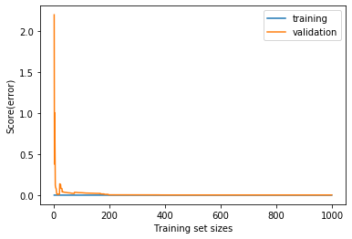

```python
#plotting learning curve
#plotting cross validation  with differenct value of depth
# plot how cross validation scores changes as we vary depth
import matplotlib.pyplot as plt
%matplotlib inline

#plt.plot(num_samples,ltrain ,'o')
#plt.plot(num_samples, lval,'o')
plt.plot(num_samples, ltrain,label='training')
plt.plot(num_samples, lval,label='validation')

#plt.plot(num_samples, ltest,label='testing')
plt.xlabel('Training set sizes')
plt.ylabel('Score(error)')
plt.legend(loc='best')
plt.savefig('Learning curve_decisiontree.png')
```

When using a simple training and test set split to select a model, the test set error may give an overly optimistic estimate of the model's performance, because the parameters were selected for best performance on the test set. Because of this, the common approach is to use a split with 3 sets: training set, validation set, and test set.

Cross-validation :- Splittng the data into 3 parts can reduce the amount of data available for training the model and also the estimated performance can vary a lot over the different training and validation splits. One possible solution for these problems is the K-fold cross-validation procedure. It consists of dividing a data set in K parts rather than using the fixed split of training and validation data. it consists of dividing a data set in K parts, K − 1 of which are used for training and one of them used for validation. The process is repeated K times, and every time a different part of the data set for the validation is used.

```python
import matplotlib.pylab as plt
from sklearn import tree
from sklearn.model_selection import cross_val_score, KFold, train_test_split

%matplotlib inline


num_folds=10
kf = KFold(n_splits=num_folds, shuffle=True)
dt1 = tree.DecisionTreeRegressor(max_depth=1)
dt2 = tree.DecisionTreeRegressor(max_depth=20)

scores1 = cross_val_score(dt1, XXtrainsyn, yytrainsyn,cv=kf,scoring='neg_mean_squared_error')
scores2 = cross_val_score(dt2, XXtrainsyn, yytrainsyn,cv=kf,scoring='neg_mean_squared_error')

print("cross validation scores:")

print("mean error tree 1:" + repr(np.mean(scores1)))
print("mean error tree 2:" + repr(np.mean(scores2)))

delta_mean = np.mean(scores1-scores2)
print("mean error difference:" +repr(delta_mean))

sdelta =np.sqrt(1./(num_folds*(num_folds-1))*np.sum(((scores1-scores2)-delta_mean)**2))

print("error stdev estimate:" +repr(sdelta))
print("CI interval: [" +repr(delta_mean- 2.23* sdelta)
      +","+repr(delta_mean+ 2.23* sdelta) +"]")
```

```
cross validation scores:
mean error tree 1:-379.19877951608964
mean error tree 2:-3.418156755384607
mean error difference:-375.78062276070506
error stdev estimate:33.92046911137004
CI interval: [-451.42326887906023,-300.1379766423499]
```

# Multilayer Perceptron

Data preprocessing :- If the data is not normalized, the neural network may have difficulty in converging before the maximum number of iterations allowed. There is a need to scale the data because the Multi-layer Perceptron is sensitive to the feature scaling. We must apply the same scaling to the test set.

For multilayer perceptron, data is very sensitive. So, we need to first scale it. we can get zero means and unit variance for each column in the data set.

Now, we can train our model. After we have a model it can be used to get the predictions. We can do this by the predict() method.

```python
from sklearn.preprocessing import StandardScaler
scaler = StandardScaler()
#plot data
# Fit only to the training data
scaler.fit(X_trainsyn)
# Now apply the transformations to the data:
X_trainsyn = scaler.transform(X_trainsyn )
X_testsyn = scaler.transform(X_testsyn )


#diabetes_y_train = scaler.transform(diabetes_y_train)
#diabetes_y_test = scaler.transform(diabetes_y_test)
```

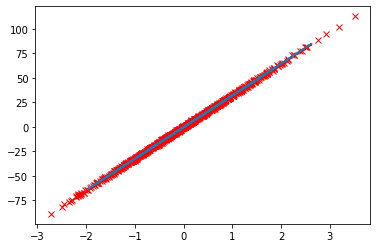

```python
from sklearn.neural_network import MLPRegressor as mlp
net = mlp(hidden_layer_sizes=(50,), activation='tanh', solver='lbfgs', max_iter=2000)
net.fit(X_trainsyn ,y_trainsyn )
p = net.predict(X_testsyn )
#plot training data
plt.plot(X_trainsyn ,y_trainsyn  ,'rx')
plt.plot(X_testsyn  ,y_testsyn  ,'r')
#plot target function
plt.plot(X_testsyn,p)
```

Now, The different hidden layers with the sizes in 1-50 have tried. For each setting, the network score is obtained on the test set and the results is plotted.

```
[0.99932753 0.99935537 0.99936323 0.99934781 0.99933007 0.99934109
 0.99934828 0.99933847 0.99935244 0.99935269 0.999334   0.99934745] [0.99945768 0.99947835 0.99947979 0.99948901 0.99950123 0.99949238
 0.99949015 0.99950038 0.99949097 0.99949002 0.99949879 0.99948878]
```

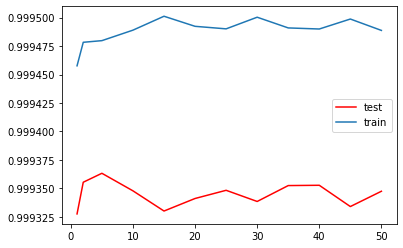

```python
import matplotlib.pyplot as pl
from sklearn.neural_network import MLPRegressor as mlp
numh = [1,2,5,10,15,20,25,30,35,40,45,50]
#numh = [1,2,5]
restest = np.zeros(len(numh))
restrain = np.zeros(len(numh))

ind=0
#ideally you would run this multiple times and report average results
#(or use cross-validation, see later)
for h in numh:
    net = mlp(hidden_layer_sizes=(h,), activation='tanh', solver='lbfgs', max_iter=2000)
    net.fit(X_trainsyn ,y_trainsyn )
    restest[ind] += net.score(X_testsyn  ,y_testsyn  )
    restrain[ind] += net.score(X_trainsyn  ,y_trainsyn   )
    ind +=1

print(restest, restrain)
#plot performance
pl.figure()
pl.plot(numh,restest,'r',label='test')
pl.plot(numh,restrain,label='train')
pl.legend()
pl.show()
```

Preventing Overfitting :-

The use of the too many hidden units will lead to the overfitting the training data. On the other hand, using too few hidden units can be a challenging task. A common way to stop the network from overfitting is to use weight decay. Weight decay can easily be implemented by adding an additional term to the cost function which penalizes large weight values. This cause the network to prefer a small or 0 weight values, limiting its representational power and thus preventing it from overfitting. Here λ is the decay parameter which determines how much the weights are penalized.

```
[-0.6536932  -0.61838865 -0.61314006 -0.51037832 -0.52183449 -0.55086645
 -0.70918292 -0.58353464 -0.65627558 -0.43735626]
[-0.68242551 -0.61895544 -0.61254352 -0.50844191 -0.49712938 -0.54431478
 -0.83778484 -0.59209825 -0.62807626 -0.47401322]
[-0.67021337 -0.60474674 -0.60863722 -0.52437059 -0.531162   -0.55447048
 -0.76564955 -0.5861018  -0.66960668 -0.48177603]
[-0.68378033 -0.60846117 -0.61089694 -0.50988227 -0.49828404 -0.55939251
 -0.93398209 -0.5942314  -0.66429274 -0.44881676]
[-0.64278289 -0.60436635 -0.60650319 -0.50665479 -0.49932688 -0.56245452
 -0.9843034  -0.58119011 -0.78903382 -0.491655  ]
[-0.63452655 -0.58832526 -0.60225837 -0.5096788  -0.50175781 -0.56364851
 -1.37729482 -0.57619637 -1.33082848 -0.4436008 ]
[-0.65726482 -0.58623014 -0.60729445 -0.60891924 -0.49008366 -0.59634513
 -4.11407496 -0.60933358 -2.78067226 -0.73957098]
```

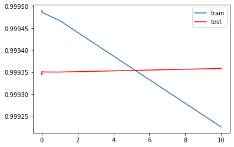

```python
import numpy as np
from sklearn.neural_network import MLPRegressor as mlp

decays=[0,0.0001,0.001,0.01,0.1,1,10]
#decays=[0,0.0001]
restest = np.zeros(len(decays))
restrain = np.zeros(len(decays))
from sklearn.model_selection import cross_val_score

ind=0
for l in decays:
    net = mlp(hidden_layer_sizes=(50,), activation='tanh',
              alpha = l, solver='lbfgs', max_iter=2000)
    scores = cross_val_score(net, X_trainsyn  ,y_trainsyn ,
                             cv=10,scoring='neg_mean_squared_error')
    print(scores)
    net.fit(X_trainsyn  ,y_trainsyn  )
    restest[ind] += net.score(X_testsyn   ,y_testsyn  )
    restrain[ind] += net.score(X_trainsyn  , y_trainsyn  )
    ind+=1

#plot performance
pl.figure()
pl.plot(decays,restrain,label='train')
pl.plot(decays,restest,'r',label='test')
pl.legend()
pl.show()
```

When using a simple training and test set split to select a model, the test set error may give an overly optimistic estimate of the model's performance, because the parameters were selected for best performance on the test set. Because of this, the common approach is to use a split with 3 sets: training set, validation set, and test set.

Cross-validation :- Splittng the data into 3 parts can reduce the amount of data available for training the model and also the estimated performance can vary a lot over the different training and validation splits. One possible solution for these problems is the K-fold cross-validation procedure. It consists of dividing a data set in K parts rather than using the fixed split of training and validation data. it consists of dividing a data set in K parts, K − 1 of which are used for training and one of them used for validation. The process is repeated K times, and every time a different part of the data set for the validation is used.

```python
import matplotlib.pylab as plt
from sklearn import tree
from sklearn.model_selection import cross_val_score, KFold, train_test_split
from sklearn.datasets import load_boston
%matplotlib inline


num_folds=10
kf = KFold(n_splits=num_folds, shuffle=True)
dt1 = tree.DecisionTreeRegressor(max_depth=1)
dt2 = tree.DecisionTreeRegressor(max_depth=10)

scores1 = cross_val_score(dt1, X_trainsyn, y_trainsyn,cv=kf,scoring='neg_mean_squared_error')
scores2 = cross_val_score(dt2, X_trainsyn, y_trainsyn,cv=kf,scoring='neg_mean_squared_error')

print("cross validation scores:")

print("mean error tree 1:" + repr(np.mean(scores1)))
print("mean error tree 2:" + repr(np.mean(scores2)))

delta_mean = np.mean(scores1-scores2)
print("mean error difference:" +repr(delta_mean))

sdelta =np.sqrt(1./(num_folds*(num_folds-1))*np.sum(((scores1-scores2)-delta_mean)**2))

print("error stdev estimate:" +repr(sdelta))
print("CI interval: [" +repr(delta_mean- 2.23* sdelta)
      +","+repr(delta_mean+ 2.23* sdelta) +"]")
```

```
cross validation scores:
mean error tree 1:-379.1622023700397
mean error tree 2:-1.5103989697573863
mean error difference:-377.65180340028235
error stdev estimate:22.22387585775332
CI interval: [-427.2110465630723,-328.0925602374924]
```

Diagnosing high bias/variance problems:

Two possible problems with the trained model are high bias and high variance. High bias models cannot represent the target hypothesis well which leads to the high error rate. On the other hand, High variance models tends to overfit the training data which results in the poor generalization. Learning curves are an easy way of determining whether a model is suffering from high bias or high variance. Learning curves plot the errors on the training set and the error on a validation set which is an estimate for generalization error for different sizes of training sets such as using 50, 100, 150, 200,.. samples for training.

Training the decision tree with max_depth=1 and with sample size 200 is as follows :-

```python
diabetes_X_trainsyn, diabetes_X_valsyn, diabetes_y_trainsyn, diabetes_y_valsyn = train_test_split(X_trainsyn,y_trainsyn)
```

Training the decision tree with max_depth=1 and with sample size 200 is as follows :-

```
Training scores:

 [       nan 1.         0.96134408 0.97272538 0.97537247 0.92024301
 0.91091326 0.80722893 0.82497686 0.73394004 0.76580808 0.78038523
 0.69372791 0.72506225 0.70986453 0.70860707 0.7262771  0.73617238
 0.71821696 0.73033057 0.74028454 0.75453253 0.76647805 0.74634256
 0.75354695 0.75833928 0.75996045 0.76568035 0.77390303 0.78331891
 0.78760841 0.76739521 0.74904437 0.75972007 0.76849071 0.77003745
 0.76175277 0.75580185 0.74783036 0.75441982 0.75943619 0.76397602
 0.75971198 0.76483896 0.76406794 0.76896644 0.76203666 0.75541253
 0.75416732 0.75768386 0.75008039 0.75490441 0.75156966 0.75551448
 0.75613875 0.74996031 0.74981063 0.75030834 0.73802111 0.7307023
 0.73522703 0.73847616 0.73936046 0.74337896 0.74074627 0.73417171
 0.73311405 0.73659789 0.71777298 0.71976789 0.72430917 0.71846127
 0.71774092 0.72224284 0.71548842 0.70853895 0.71286783 0.71252035
 0.71453601 0.71455479 0.70816619 0.70272385 0.69792304 0.7008821
 0.70093732 0.70308918 0.70639749 0.69978971 0.70195874 0.70483027
 0.70183246 0.70165226 0.7010277  0.70448694 0.70710086 0.70474003
 0.70503823 0.70378004 0.6991837  0.69500468 0.69621857 0.69421669
 0.69261086 0.69280092 0.69504488 0.69595351 0.69738232 0.69129121
 0.6947382  0.69485935 0.69615006 0.69714699 0.70043295 0.70260249
 0.69937117 0.70061165 0.69814231 0.6987627  0.70075485 0.70264704
 0.69732195 0.69952297 0.69604863 0.69775955 0.69794378 0.69828679
 0.69631748 0.69881198 0.6994248  0.69622774 0.69790879 0.69398941
 0.69490561 0.69650998 0.69908781 0.69905592 0.6985661  0.69710671
 0.69768373 0.69925628 0.6960271  0.69712261 0.69024322 0.69027737
 0.6888885  0.68865079 0.68946172 0.69064178 0.68658271 0.68745272
 0.68359955 0.68066831 0.67632815 0.67427108 0.67300707 0.67300496
 0.66888745 0.67062165 0.66725672 0.66421926 0.66028217 0.66010837
 0.66193936 0.66183165 0.66304522 0.66054225 0.66148927 0.65959105
 0.65610621 0.65747467 0.65869487 0.66063775 0.65870954 0.65999939
 0.65808281 0.6589648  0.65588554 0.65343805 0.65529674 0.65439604
 0.65150739 0.64898516 0.65109906 0.65253268 0.65431324 0.65474519
 0.65198649 0.65319419 0.65070435 0.65090338 0.650929   0.65333064
 0.65337968 0.65293196 0.6552772  0.65281338 0.65194596 0.65076542
 0.6515101 ]

 ----------------------------------------------------------------------

Validation scores:
```

[output cut: 20 more lines]

```
  0.58165112  0.58221175  0.58403398  0.58479558  0.58404443  0.58339842
  0.58657881  0.5865322   0.58842515  0.58859952  0.58950059  0.58621929
  0.58816113  0.58634893  0.58694372  0.58914978  0.58868071  0.59093762
  0.59119352  0.5897356   0.58930254  0.59021835  0.58712668  0.5833273
  0.58399296  0.58338036  0.58504471  0.58541433  0.57701973  0.57796753
  0.58188238  0.57633835  0.57689904  0.57447516  0.57647999  0.57678815
  0.57856075  0.58088911  0.58385804  0.58534899  0.58650464  0.58739167
  0.58939104  0.58870547  0.59023135  0.59200183  0.59357644  0.59426916
  0.59416006  0.59480168  0.59474829  0.59807054  0.59807488  0.59930907
  0.6008787   0.6000295   0.60024374  0.59880605  0.5999512   0.59900678
  0.59996406  0.59992621  0.60120717  0.60208924  0.60207333  0.60284263
  0.60366893  0.60246706  0.60214148  0.60214729  0.60421913  0.60448023
  0.60566697  0.60540209  0.60429046  0.60483134  0.60523222  0.6046001
  0.60494642  0.60549664  0.60507093  0.60576702  0.60619929  0.60475846
  0.60495118]
```

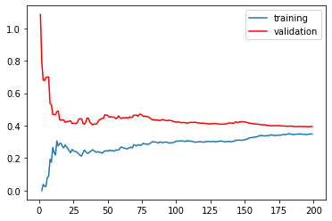

```python
from sklearn import tree
num_samples = np.arange(1,200)
depth=1
trainscore = np.zeros(len(num_samples))
valscore = np.zeros(len(num_samples))
for idx,samples in enumerate(num_samples):
    model = tree.DecisionTreeRegressor(max_depth=depth)
    model.fit(diabetes_X_trainsyn[0:samples,:],diabetes_y_trainsyn[0:samples])
    trainscore[idx] = model.score(diabetes_X_trainsyn[0:samples,:],diabetes_y_trainsyn[0:samples])
    valscore[idx] = model.score(diabetes_X_valsyn,diabetes_y_valsyn)
print('Training scores:\n\n', trainscore)
print('\n', '-' * 70) # separator to make the output easy to read
print('\nValidation scores:\n\n', valscore)
plt.figure()
#plt.ylim((-0.1,0.5))
#error rate = 1.0 - accurracy
plt.plot(num_samples,1.0-trainscore,label='training')
plt.plot(num_samples,1.0-valscore,'r',label='validation')
plt.legend()
```

The error on the training set and the validation sets are typically close, and both they are high. The model is suffering from a high bias.

Training the decision tree with max_depth=10 and sample size 200 is as follows :-

```
Training scores:

 [       nan 1.         1.         1.         1.         1.
 1.         1.         1.         1.         1.         1.
 1.         1.         1.         1.         1.         1.
 1.         1.         1.         1.         1.         1.
 1.         1.         1.         1.         1.         1.
 1.         1.         1.         1.         1.         1.
 1.         1.         1.         1.         1.         1.
 1.         1.         1.         1.         1.         1.
 1.         1.         1.         1.         1.         1.
 1.         1.         1.         1.         1.         1.
 1.         1.         1.         1.         1.         1.
 1.         1.         1.         1.         1.         1.
 1.         1.         1.         1.         1.         1.
 1.         1.         1.         1.         1.         1.
 1.         1.         1.         1.         1.         1.
 1.         1.         1.         1.         1.         1.
 1.         1.         1.         1.         1.         1.
 1.         1.         1.         1.         1.         1.
 1.         1.         1.         1.         1.         1.
 1.         1.         1.         1.         1.         0.99999998
 1.         1.         1.         1.         1.         0.99999998
 0.99999905 0.99999907 0.99999907 0.99999907 0.99999909 0.99999909
 0.9999991  0.99999911 0.99999911 0.99999912 0.99999914 0.99999916
 0.99999916 0.99999915 0.99999915 0.99999916 0.99999999 0.99999999
 0.99999919 0.99999999 0.99999999 0.99999999 0.99999999 0.99999999
 0.99999995 0.99999995 0.99999995 0.99999995 0.99999995 0.99999995
 0.99999995 0.99999995 0.99999995 0.99999995 0.99999995 0.99999995
 0.99999999 0.99999999 0.99999999 0.99999924 0.99999924 0.99999924
 0.99999924 0.99999925 0.99999925 0.99999927 0.99999927 0.99999927
 0.99999927 0.99999928 0.99999928 0.99999928 0.99999928 0.99999928
 0.99999928 0.99999999 0.99999999 0.99999999 0.99999929 0.99999929
 0.99999929 0.99999926 0.99999922 0.99999928 0.99999928 0.99999929
 0.99999929 0.99999929 0.9999993  0.9999993  0.9999993  0.99999932
 0.99999932]

 ----------------------------------------------------------------------

Validation scores:
```

[output cut: 20 more lines]

```
  0.99692542  0.99682046  0.99682172  0.99684514  0.99684594  0.99685845
  0.99685684  0.99685684  0.9968486   0.9968486   0.99684888  0.99684849
  0.99684376  0.99705603  0.99706988  0.99706988  0.99707214  0.99706194
  0.99707257  0.99707257  0.9970783   0.99709523  0.99709523  0.99708057
  0.9971479   0.9971482   0.9971482   0.99715903  0.99716064  0.99716171
  0.99716014  0.99716175  0.99716175  0.99716175  0.99716199  0.99716782
  0.99716782  0.99716782  0.99718083  0.99725366  0.99727805  0.99730946
  0.9973113   0.99736859  0.99736252  0.99736252  0.9973602   0.9973602
  0.99736836  0.99736836  0.99735317  0.99734998  0.99734998  0.99735887
  0.99735419  0.9973524   0.9973925   0.9973925   0.99739029  0.99740267
  0.99740267  0.9974223   0.99739751  0.99739751  0.99739751  0.99738487
  0.99738487  0.99737986  0.99737986  0.99737986  0.99738558  0.99740303
  0.99742859  0.99742829  0.99742829  0.99759969  0.99760181  0.997657
  0.99768698  0.99767708  0.99767708  0.99770029  0.99770729  0.99809607
  0.99809031]
```

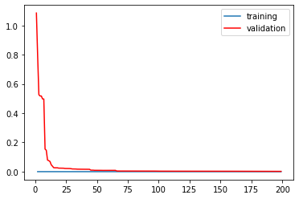

```python
num_samples = np.arange(1,200)
depth=10
train_score1 = np.zeros(len(num_samples))
val_score1 = np.zeros(len(num_samples))
for idx,samples in enumerate(num_samples):
    model = tree.DecisionTreeRegressor(max_depth=depth)
    model.fit(diabetes_X_trainsyn[0:samples,:],diabetes_y_trainsyn[0:samples])
    train_score1[idx] = model.score(diabetes_X_trainsyn[0:samples,:],diabetes_y_trainsyn[0:samples])
    val_score1[idx] = model.score(diabetes_X_valsyn,diabetes_y_valsyn)
print('Training scores:\n\n', train_score1)
print('\n', '-' * 70)
print('\nValidation scores:\n\n', val_score1)
plt.figure()
#plt.ylim((-0.1,0.5))
#error rate = 1.0 - accurracy
plt.plot(num_samples,1.0-train_score1,label='training')
plt.plot(num_samples,1.0-val_score1,'r',label='validation')
plt.legend()
```

Trying the values for tree depth in the range 1-40 and plotting the validation and training error for these values.

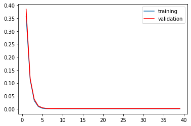

```python
from sklearn import metrics
from sklearn.tree import DecisionTreeRegressor

max_d = np.arange(1,40)

train_score = np.zeros(len(max_d))
val_score = np.zeros(len(max_d))


for idx,depth in enumerate(max_d):
    model = DecisionTreeRegressor(max_depth=depth)
    model.fit(diabetes_X_trainsyn,diabetes_y_trainsyn)
    train_score[idx] = model.score(diabetes_X_trainsyn,diabetes_y_trainsyn)
    val_score[idx] = model.score(diabetes_X_valsyn,diabetes_y_valsyn)


plt.figure()
plt.plot(max_d,1.0-train_score,label='training')
plt.plot(max_d,1.0-val_score,'r',label='validation')


plt.legend()
```

In this case, till the depth 5 of decision tree, the model error is same on training set and validation set, afterwards the validation set error is constant.

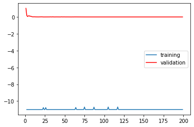

```python
# Bias and variance For neural network model with sample size 200
import numpy as np
import matplotlib.pyplot as pl
from sklearn.neural_network import MLPRegressor as mlp

num_samples = np.arange(1,200)

train_scoren = np.zeros(len(num_samples))
val_scoren = np.zeros(len(num_samples))
numh = [1,2,5,10,15,20,25,30,35,40,45,50]
#numh = [1,2,5]

ind=0
#ideally you would run this multiple times and report average results
#(or use cross-validation, see later)
for idx,samples in enumerate(num_samples):
    for h in numh:
        net = mlp(hidden_layer_sizes=(h,), activation='tanh', solver='lbfgs', max_iter=1000)
        net.fit(diabetes_X_trainsyn[0:samples,:],diabetes_y_trainsyn[0:samples])
        train_scoren[idx] += net.score(diabetes_X_trainsyn[0:samples,:],diabetes_y_trainsyn[0:samples])
        val_scoren[idx] = net.score(diabetes_X_valsyn,diabetes_y_valsyn)
        ind +=1



#plot performance
pl.figure()
plt.plot(num_samples,1.0-train_scoren,label='training')
plt.plot(num_samples,1.0-val_scoren,'r',label='validation')
pl.legend()
pl.show()
```

Compare Models

```python
tree = DecisionTreeRegressor(max_depth=20)
tree.fit(X_trainsyn,y_trainsyn)
```

```
DecisionTreeRegressor(criterion='mse', max_depth=20, max_features=None,
                      max_leaf_nodes=None, min_impurity_decrease=0.0,
                      min_impurity_split=None, min_samples_leaf=1,
                      min_samples_split=2, min_weight_fraction_leaf=0.0,
                      presort=False, random_state=None, splitter='best')
```

```python
from sklearn.neural_network import MLPRegressor as mlp
mlp_model = mlp(hidden_layer_sizes=(50,), alpha=0.1,activation='tanh', solver='lbfgs', max_iter=2000)
mlp_model.fit(X_trainsyn,y_trainsyn  )
```

```
MLPRegressor(activation='tanh', alpha=0.1, batch_size='auto', beta_1=0.9,
             beta_2=0.999, early_stopping=False, epsilon=1e-08,
             hidden_layer_sizes=(50,), learning_rate='constant',
             learning_rate_init=0.001, max_iter=2000, momentum=0.9,
             n_iter_no_change=10, nesterovs_momentum=True, power_t=0.5,
             random_state=None, shuffle=True, solver='lbfgs', tol=0.0001,
             validation_fraction=0.1, verbose=False, warm_start=False)
```

```python
from sklearn.externals import joblib
# Save the model as a pickle in a file
joblib.dump(tree, 'tree_model.pkl')

# Save the model as a pickle in a file
joblib.dump(mlp_model, 'mlp_model.pkl')
```

```
['mlp_model.pkl']
```

```python
model1 = joblib.load('tree_model.pkl')
model2 = joblib.load('mlp_model.pkl')
```

Test score of both models:

```python
print(model2.score(X_trainsyn,y_trainsyn))
```

```
0.9994842116456402
```

```python
print(model1.score(XXvalsyn,yyvalsyn))
print(model2.score(X_testsyn , y_testsyn))
```

```
0.9984694961913908
0.9993503541052621
```

Visualizing the predicted and actual y

```python
predicted_y_mlp=model2.predict(X_testsyn)
actual_y_mlp=y_testsyn
y_predicted_inverse = scaler.inverse_transform(predicted_y_mlp)
y_actual_inverse = scaler.inverse_transform(actual_y_mlp)
```

```python
 predicted_y_tree=model1.predict(diabetes_X_test)
```

Plotting the predicted y with actual output for both the models

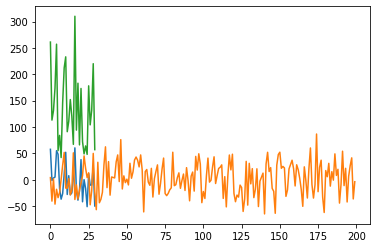

```python
plt.plot(predicted_y_tree)
plt.plot(y_predicted_inverse)
plt.plot(diabetes_y_test)
```

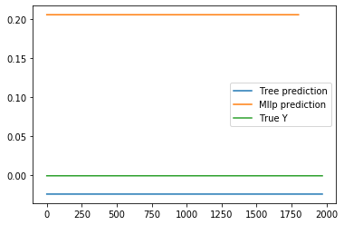

```python
 def moving_average(x, w):
    return np.convolve(x, np.ones(w), 'valid') / w

tree_predict_y=predicted_y_tree
tree_predict_y.ravel()

tree_predict_y=moving_average(tree_predict_y, 2000)

mlp_predict_y=y_predicted_inverse
mlp_predict_y.ravel()

mlp_predict_y=moving_average(mlp_predict_y, 2000)

actual_value_y=diabetes_X_test
actual_value_y=actual_value_y[:, 0]

actual_value_y=moving_average(actual_value_y, 2000)


plt.plot(tree_predict_y,label='Tree prediction')
plt.plot(mlp_predict_y,label='Mllp prediction')
plt.plot(actual_value_y,label='True Y')
plt.legend()
```

Research Question:-

What is the effect of outliers data on performance of multilayer perceptron?

First, by examining the percentage outliers and Secondly, the magnitude outliers.